# Proyecto

Moisés Alvarado Hermida

2024-04-04

## Fuente de datos

Fuente: [INEGI, Vehículos de Motor Registrados en Circulación](https://www.inegi.org.mx/programas/vehiculosmotor/#datos_abiertos)

```r
##Carga de datos
datos <- read.csv("vmrc_anual_tr_cifra_2022.csv")
entidades <- read.csv("tc_entidad.csv")
library(ggplot2)
```

# 1. Objetivo

Analizar y aplicar los conceptos relacionados con el Curso de R a los datos e información recopilados por el INEGI relacionados con el registro de Vehículos de Motor registrados en Circulación.

# 2. Justificación

La revisión de los datos recopilados por el INEGI relacionados con el registro de vehículos de motor que circulan o circularon por las diferetnes calles, avenidas, carreteras y caminos aporta información relacionada con las actividades económicas, sociales y culturales.

Adicionalmente con esta información no solo puede vertir conocimiento sobre la demanda de produción sobre su demanda, su actividad, la predilección de la población por algún tipo o tamaño, sino también las necesidades que se tienen en cuanto a los materiales requeridos para su mantenimiento, operación, espacios, etc.

```r
## numero de autos en circulacion tendencia a los particualesres de todos los datos
numeroTotalAUTO_OFICIAL <- sum(datos$AUTO_OFICIAL)
numeroTotalAUTO_OFICIAL
```

```
## [1] 62273
```

```r
numeroTotalAUTO_PUBLICO <- sum(datos$AUTO_PUBLICO)
numeroTotalAUTO_PUBLICO
```

```
## [1] 678281
```

```r
numeroTotalAUTO_PARTICULAR <- sum(datos$AUTO_PARTICULAR)
numeroTotalAUTO_PARTICULAR
```

```
## [1] 35756325
```

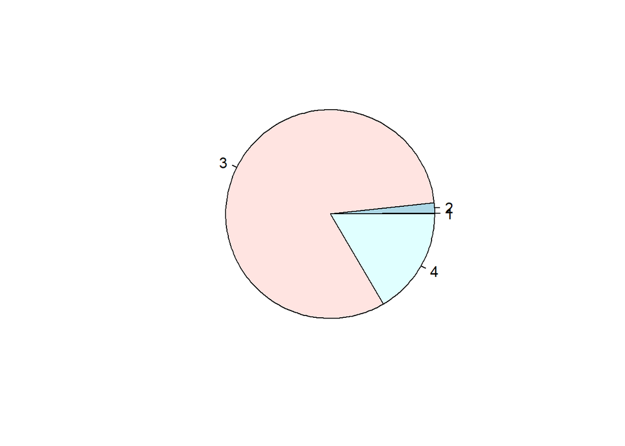

```r
numeroTotalOtroCiculacion <-
  sum(datos$CAM_PAS_OFICIAL) + sum(datos$CAM_PAS_PUBLICO) +
  sum(datos$CYC_CARGA_OFICIAL) + sum(datos$CYC_CARGA_PUBLICO) +
  sum(datos$MOTO_OFICIAL) + sum(datos$MOTO_DE_ALQUILER) +
  sum(datos$MOTO_PARTICULAR)
vectorTotal <- c(sum(datos$AUTO_OFICIAL),sum(datos$AUTO_PUBLICO),sum(datos$AUTO_PARTICULAR),sum(numeroTotalOtroCiculacion))
## los datos de grafica tienen tendencia hacia carro particular que donde se tiene un mayor numero de registtros
pie(vectorTotal)
```

## Comparacion de Publico vs particular

CAM_PAS_PUBLICO,“Comprende los autobuses urbanos y suburbanos, microbuses, camiones escolares, camionetas pick-up (utilizadas para el transporte de trabajadores), ómnibus y en general, los vehículos con más de 7 asientos, destinados al transporte público o privado de personas. Es el servicio que prestan las personas físicas y morales al público en general, para el traslado de pasajeros y bienes a diferentes lugares del país, utilizando los caminos y puentes de Jurisdicción Federal, mediante una concesión otorgada por la Secretaría de Comunicaciones y Transportes.”

AUTO_PUBLICO,“Comprende los vehículos a motor (excepto motocicletas) destinados al transporte de personas, que tengan hasta 7 asientos (incluyendo el del conductor). Es el servicio que prestan las personas físicas y morales al público en general, para el traslado de pasajeros y bienes a diferentes lugares del país, utilizando los caminos y puentes de Jurisdicción Federal, mediante una concesión otorgada por la Secretaría de Comunicaciones y Transportes.”

# 3. Análisis exploratorio de los datos(Estadística descriptiva)

```r
numeroTotalPublico <- sum(datos$CAM_PAS_PUBLICO) + sum(datos$AUTO_PUBLICO) + sum(datos$CYC_CARGA_PUBLICO)
numeroTotalPublico
```

```
## [1] 986705
```

```r
numeroTotalParticular <- sum(datos$CAM_PAS_PARTICULAR) + sum(datos$AUTO_PARTICULAR) + sum(datos$CYC_CARGA_PARTICULAR)
numeroTotalParticular
```

```
## [1] 47217595
```

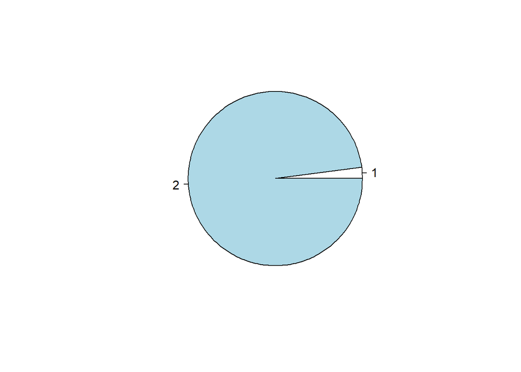

```r
vectorPublicoPrivado<- c(numeroTotalPublico,numeroTotalParticular)

pie(vectorPublicoPrivado)
```

## AUTOS PARTICULAES

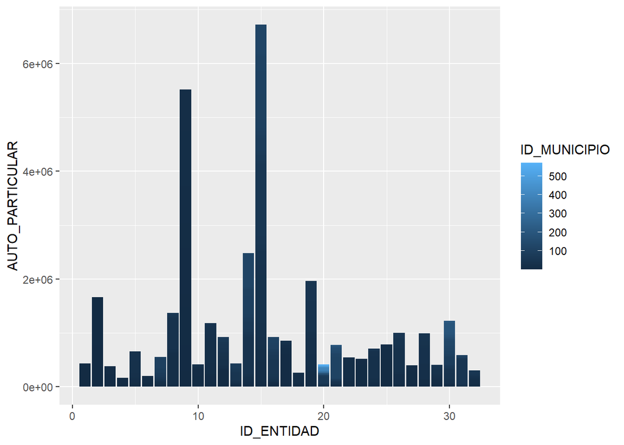

```r
ggplot(datos , aes(x=ID_ENTIDAD,  y=AUTO_PARTICULAR ,fill = ID_MUNICIPIO)) + geom_col()
```

## media,mediana,varianza,Desviación Estándar total

# 4. Análisis estadístico inferencial

```r
## es el dato mas llamativo porque no tienes ceros en la tablas en las otras medias tendencia a cero se tendria que hacer una ponderacion de datos para calcular las otras

## media total
mean(datos$AUTO_PARTICULAR)
```

```
## [1] 14482.11
```

```r
# mediana total
median(datos$AUTO_PARTICULAR)
```

```
## [1] 1107
```

```r
# varianza
var(datos$AUTO_PARTICULAR)
```

```
## [1] 3939569804
```

```r
# Desviación Estándar
sd(datos$AUTO_PARTICULAR)
```

```
## [1] 62765.99
```

```r
#numero total por el pais
numeroTotalAUTO_PARTICULAR
```

```
## [1] 35756325
```

# 5. Resultados

## Cuidad de México

```r
CiudadMexico<- subset(datos,datos$ID_ENTIDAD==9)
## media total
mediaDF<-mean(CiudadMexico$AUTO_PARTICULAR)
mediaDF
```

```
## [1] 344459.6
```

```r
# mediana total
median(CiudadMexico$AUTO_PARTICULAR)
```

```
## [1] 343116
```

```r
# varianza
var(CiudadMexico$AUTO_PARTICULAR)
```

```
## [1] 37053862973
```

```r
# Desviación Estándar
sd(CiudadMexico$AUTO_PARTICULAR)
```

```
## [1] 192493.8
```

```r
#numero total por el estado
sum(CiudadMexico$AUTO_PARTICULAR)
```

```
## [1] 5511353
```

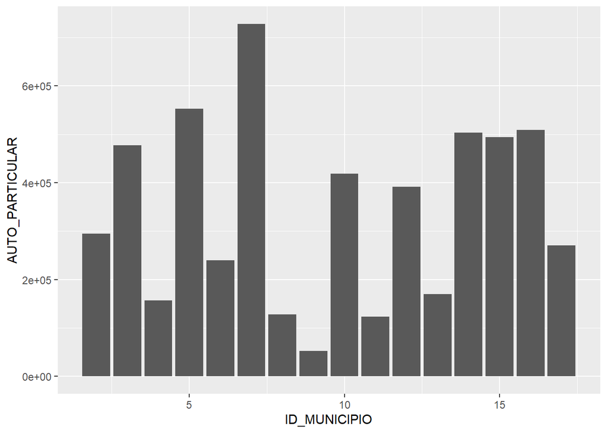

```r
ggplot(CiudadMexico, aes(x=ID_MUNICIPIO,  y=AUTO_PARTICULAR )) + geom_col()
```

## Estado de México

```r
Mexico<- subset(datos,datos$ID_ENTIDAD==15)
## media total
mediaMexico <- mean(Mexico$AUTO_PARTICULAR)
mediaMexico
```

```
## [1] 53744.22
```

```r
# mediana total
median(Mexico$AUTO_PARTICULAR)
```

```
## [1] 9993
```

```r
# varianza
var(Mexico$AUTO_PARTICULAR)
```

```
## [1] 16766212544
```

```r
# Desviación Estándar
sd(Mexico$AUTO_PARTICULAR)
```

```
## [1] 129484.4
```

```r
#numero total por el estado
sum(Mexico$AUTO_PARTICULAR)
```

```
## [1] 6718027
```

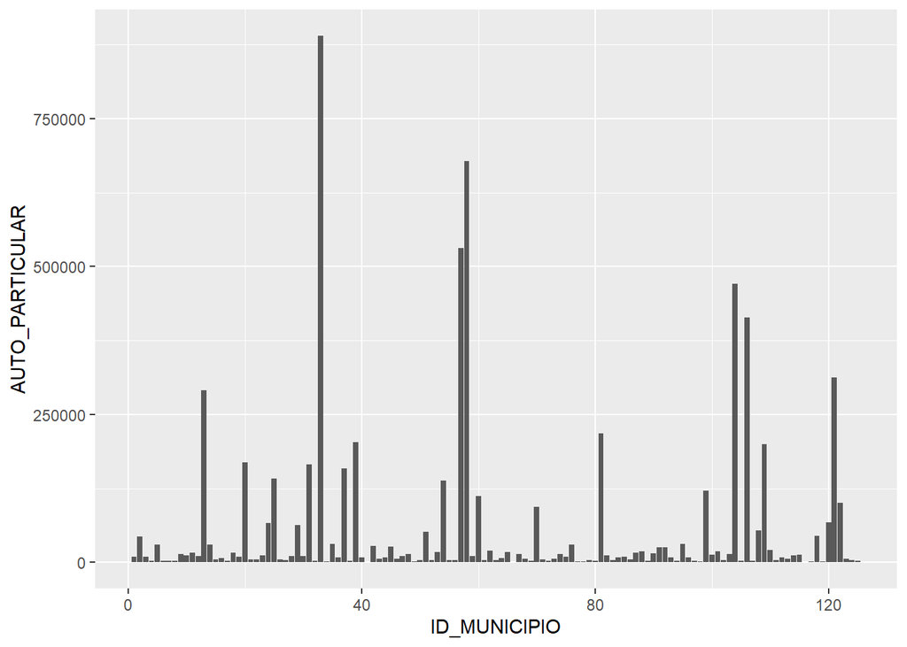

```r
ggplot(Mexico, aes(x=ID_MUNICIPIO,  y=AUTO_PARTICULAR )) + geom_col()
```